# Untitled

Marton Kovacs

21 január, 2020

# Load packages

```r
library(tidyverse)
library(readxl)
```

# Investigating the journals in the science direct database

In our study we collected email addresses of authors who published in one of the Science Direct Journals that is labelled as psychology (see the following link for the journals and their labels: https://www.sciencedirect.com/browse/journals-and-books?contentType=JL&subject=psychology).

## Import data

The list of journals and their subfields at the time of the data collection.

```r
journal <- read_csv2("Data/ContactDatabase/ReMis_Sample_Journal.csv",
                     locale = locale(encoding = "ISO-8859-13"))
```

At the time of our data collection there were 203 journals in the Science Direct database.

# Investigating our contact database

We used a scraping code to collect meta information of published articles in the Science Direct database.

## Import data

```r
email <- read_csv("Data/ContactDatabase/ReMis_Sample_Raw.csv",
                  locale = locale(encoding = "UTF-8")) %>%
  distinct(email, .keep_all = TRUE)
```

## Descriptive statistics of our collection

### Number of articles

We have downloaded the metainformation of 59672 individual articles.

We could extract the email addresses of 59671 corresponding authors of these articles. This does not mean that all email addresses are working as the automatized scraper code coulde make mistakes.

### Number of journals

Saving the distinct journal titles from our collection.

```r
email_publication <-
  email %>%
  distinct(publicationname)
```

We collected articles from 153 journals out of the full Science Direct database.

There are journals that are in the Science Direct database but we did not collect any articles from them. Save the list of these journals.

```r
journal_missing <-
  journal %>%
  distinct(publicationname) %>%
  anti_join(., email_publication, by = "publicationname")
```

There were 50 that we did not collect any article from.

# Investigating the randomly selected sample for the main survey

After the selection we tried to fin the last name or the email address of the author if it was missing by hand.

## Import data

```r
# batch 3
batch_3_cleaned <- read_csv("Data/Samples/ReMis_Main_181126_3Batch_Cleaned.csv")

# batch 5
batch_5_cleaned <- read_csv("Data/Samples/ReMis_Main_181129_5Batch_Cleaned.csv")

# batch 6
batch_6_cleaned <- read_csv("Data/Samples/ReMis_Main_181210_6Batch_Cleaned.csv")
```

We used the Qualtrics mail sender to send out our survey. Therefore now, we load the metadata of our samples downloaded from the Qualtrics mail sender history.

```r
# batch 3
batch_3_history <- read_csv2("Data/MailSender_History/ReMis_Main_History_Batch_3.csv")

# batch 5
batch_5_history <- read_csv2("Data/MailSender_History/ReMis_Main_History_Batch_5.csv")

# batch 6
batch_6_history <- read_csv2("Data/MailSender_History/ReMis_Main_History_Batch_6.csv")
```

## Renaming variables

We rename some variables to make the datasets comperable.

```r
# batch 3
batch_3_history <-
  batch_3_history %>%
  rename(email = Email,
         last_name = `Last Name`,
         status = Status)

batch_3_cleaned <-
  batch_3_cleaned %>%
  rename(last_name = surname)

# batch 5
batch_5_history <-
  batch_5_history %>%
  rename(email = Email,
         last_name = `Last Name`,
         status = Status)

batch_5_cleaned <-
  batch_5_cleaned %>%
  rename(last_name = surname)

# batch 6
batch_6_history <-
 batch_6_history %>%
  rename(email = Email,
         last_name = `Last Name`,
         status = Status)

batch_6_cleaned <-
  batch_6_cleaned %>%
  rename(last_name = surname)
```

## Descriptives of the used samples

There are 500 email addresses in the sample of batch 3. For batch 3 there were 0 missing email addresses and 0 missing last names. There were 500 emails sent out to this sample.

There are 1000 email addresses in the sample of batch 5. For batch 5 there were 0 missing email addresses and 0 missing last names. There were 1000 emails sent out to this sample.

There are 15000 email addresses in the sample of batch 6. For batch 6 there were 10 missing email addresses and 78 missing last names. There were 14913 emails sent out to this sample.

## Exclusion from the samples

For a few authors we coud not find the last name or the email address in the sample of batch 6. We are saving these incomplete instances now.

```r
batch_6_missing <-
  batch_6_cleaned %>%
  filter(is.na(last_name) | is.na(email))
```

We are checking the difference between the cleaned sample and the survey history.

```r
batch_6_cleaned_history_difference <-
  setdiff(
    select(batch_6_cleaned, email, last_name),
    select(batch_6_history, email, last_name)
    )
```

There are 89 data points that differ in the sample in opposition to the survey history. 88 of these differing data points are the ones that miss either the last name or the email address of the author, so they were dropped during cleaning up. 1 data point is differing because there is a difference in the last name addded during the cleaning up.

We are checking the difference between the survey history and the cleaned sample.

```r
batch_6_history_cleaned_difference <-
  setdiff(
    select(batch_6_history, email, last_name),
    select(batch_6_cleaned, email, last_name)
    )
```

There are 2 data points that differ in the survey history in opposition to the sample. One of these data points is the one with different wording in the last name that we have found in the comparison before. In addition, one of the coauthors was added to the email list as a final check.

We are excluding the coauthor from the survey history.

```r
batch_6_history <-
  batch_6_history %>%
  filter(last_name != "Aczel")
```

## Joining sample with history

Finish the cleaning of the sample we join the information in the sample to the email addresses in the survey history.

```r
# Batch 3
batch_3_sample <-
  batch_3_history %>%
  left_join(., batch_3_cleaned, by = c("email", "last_name"))

# Batch 5
batch_5_sample <-
  batch_5_history %>%
  left_join(., batch_5_cleaned, by = c("email", "last_name"))

# Batch 6
batch_6_sample <-
  batch_6_history %>%
  left_join(., batch_6_cleaned, by = c("email", "last_name"))
```

The final sample size for batch 3 is 500

The final sample size for batch 5 is 1000

The final sample size for batch 6 is 14912

## Joining samples

We join all the three samples to one dataframe.

```r
sample <-
  batch_3_sample %>%
  bind_rows(batch_5_sample) %>%
  bind_rows(batch_6_sample)
```

Checking the send status of the emails.

```r
sample %>%
  group_by(status) %>%
  count()
```

```
## # A tibble: 6 x 2
## # Groups:   status [6]
##   status                         n
##   <chr>                      <int>
## 1 Email Bounced               2379
## 2 Email Sent                 13095
## 3 Finished Survey              481
## 4 Opted Out                    211
## 5 Partially Completed Survey   223
## 6 Started Survey                23
```

# Investigating the journals in our sample

A lot of the respondents to our survey indicated that their subfield is not on the list of preset subfields that we provided in our survey. We believed that the range of subfields listed cover the field of psychology. It is possible that our respondents were not exclusivly psychologist, just published in a paper that is labelled as psychology in the Science Direct database. Therefore, now we list the titles of the journals where the authors in our sample published in.

```r
sample_publication <-
  sample %>%
  distinct(publicationname)
```

We have 151 distinct journals in our sample.

We are checking the list of publications that our in our whole database but were not selected when we created our sample.

```r
email_publication %>%
  anti_join(., sample_publication, by = "publicationname")
```

```
## # A tibble: 2 x 1
##   publicationname
##   <chr>
## 1 Applied and Preventive Psychology
## 2 Woman - Psychosomatic Gynaecology and Obstetrics
```

There were 1 researchers in the sample where the journal is not known.

# Exploring journal subfield in our sample

We are adding the subfield descriptions from the Science Direct database to our sample.

```r
sample_match_journal <-
  sample_publication %>%
  inner_join(., journal, by = "publicationname")
```

```r
sample_match_journal %>%
  arrange(publicationname) %>%
  write_tsv(., "Data/Processed/ReMis_Main_SampleJournals.tsv")
```

We are checking the number of subfields that a journal is assigned to.

```r
sample_match_journal %>%
  group_by(publicationname) %>%
  summarise(n_subfields = n()) %>%
  group_by(n_subfields) %>%
  summarise(n_journals = n())
```

```
## # A tibble: 4 x 2
##   n_subfields n_journals
##         <int>      <int>
## 1           1         91
## 2           2         47
## 3           3         11
## 4           4          2
```

On plot the same thing.

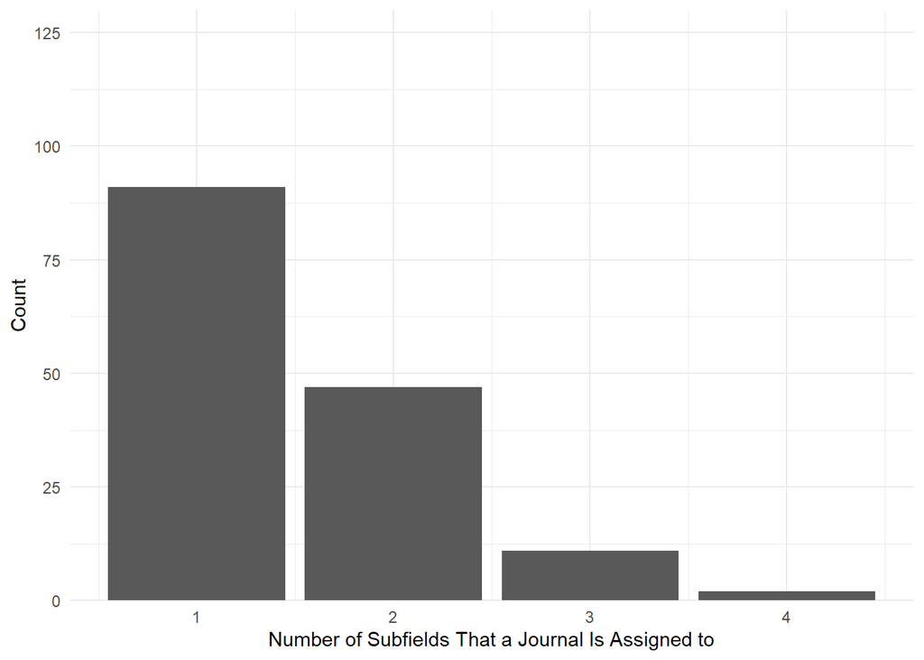

```r
sample_match_journal %>%
  group_by(publicationname) %>%
  summarise(n = n()) %>%
  arrange(desc(n)) %>%
  ggplot() +
  aes(x = n) +
  geom_bar() +
  scale_y_continuous(expand = c(0,0), limits = c(0, 130)) +
  labs(x = "Number of Subfields That a Journal Is Assigned to", y = "Count") +
  theme_minimal()
```

Number of journals assinged to each subfield. Please keep in mind that a journal can be assigned to more than one subfield.

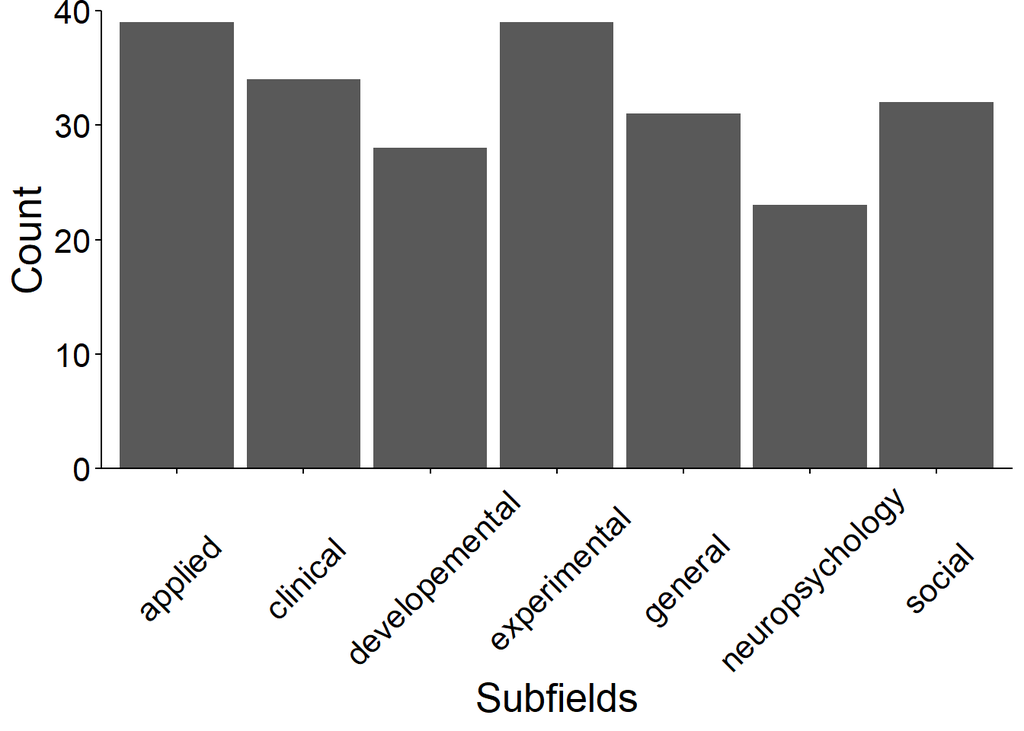

```r
sample_match_journal %>%
  group_by(subfield) %>%
  summarise(n = n()) %>%
  ggplot() +
  aes(x = subfield, y = n) +
  geom_bar(stat = "identity") +
  scale_y_continuous(expand = c(0,0), limits = c(0, 40)) +
  labs(x = "Subfields", y = "Count") +
  theme_minimal() +
  theme(axis.text.x = element_text(angle = 45, vjust = 0.5),
        axis.ticks = element_line(color = "black"),
        axis.line = element_line(color = "black"),
        axis.text = element_text(color = "black", size = 16),
        axis.title = element_text(size = 20),
        panel.background = element_blank(),
        panel.grid = element_blank())
```

Saving the plot.

```r
ggsave("Figures/sample_journal_subfield_plot.png", width = 14.4, height = 8, plot = last_plot())
```